# Late Exaggeration

May 12, 2018

Up: [Documentation Home](https://jlmelville.github.io/smallvis/).

The [FIt-SNE](https://arxiv.org/abs/1712.09005) paper recommends the technique of “late exaggeration”. This is exactly the same as early exaggeration (multiply the input probabilities by a fixed constant), but doing it at the end of the optimization, rather than the beginning. This seems to have the effect of forcing any clusters to be tighter and further apart, which makes for better visualizations. The effect seems reminiscent of the output of LargeVis and UMAP, in fact.

In the paper, the authors set the exaggeration factor to 12 for the last 250 iterations of an embedding of the entire MNIST digits dataset, which mirrors the recommended setting for early exaggeration with large datasets.

## Datasets

See the [Datasets](https://jlmelville.github.io/smallvis/datasets.html) page.

## Settings

Settings will be the same as the [original t-SNE paper](http://www.jmlr.org/papers/v9/vandermaaten08a.html), except with scaled PCA initialization rather than random initialization. Given that the example in the FIt-SNE paper used late exaggeration settings that matched the default early exaggeration settings, we shall do the same here, except that the length and extent of the early exaggeration is lessened for the sort of datasets that can be handled by `smallvis`: the `exaggeration_factor` will be `4`, and will run for the last 100 iterations:

```
iris_late_ex <- smallvis(iris, perplexity = 40, Y_init = "spca", eta = 100,
                            exaggeration_factor = 4, stop_lying_iter = 100,
                            late_exaggeration_factor = 4, start_late_lying_iter = 900)
```

Initial results suggested that the exaggeration factor of 4 was a too high for late exaggeration, so we will also look at reduced `late_exaggeration_factor` values of `2` and `1.5`. The early exaggeration factor is unchanged at 4 in these cases. I looked at also reducing the early exaggeration factor when the late exaggeration factor was reduced, but it doesn’t have much of an effect, so we needn’t worry about that.

We’ll also compare results with the standard t-SNE with early exaggeration only:

```
iris_tsne <- smallvis(iris, perplexity = 40, Y_init = "spca", eta = 100,
                      exaggeration_factor = 4, stop_lying_iter = 100)
```

## Evaluation

Apart from visualizing the results, the mean neighbor preservation of the 40 closest neighbors (in line with the `perplexity`) is used to provide a rough quantification of the quality of the result. On the plots, this is labelled as `mnp@40`.

## Results

For each dataset, the top left image is the result of using late exaggeration with an exaggeration factor of 4, the top right is with an exaggeration factor of 2, and the bottom left is with an exaggeration factor of 1.5. The bottom right is standard t-SNE with no late exaggeration. All results used early exaggeration with an exaggeration factor of 4.

### iris

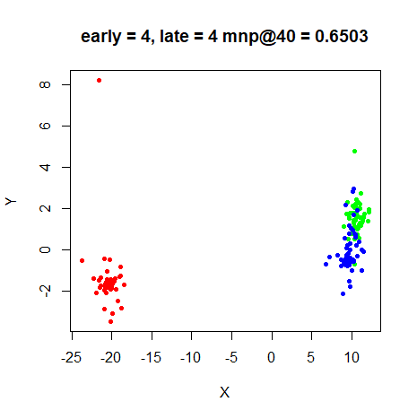

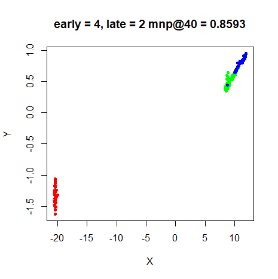

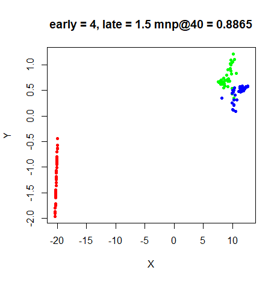

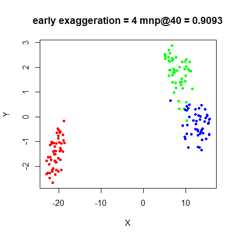

### s1k

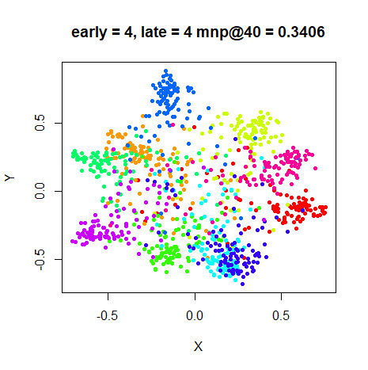

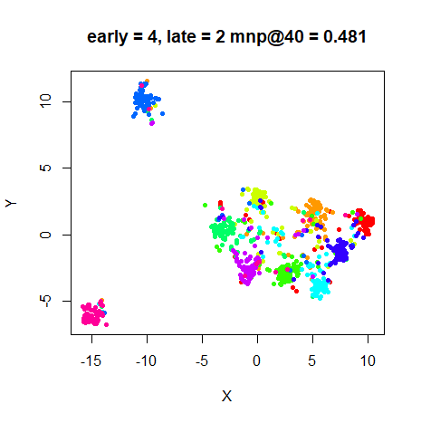

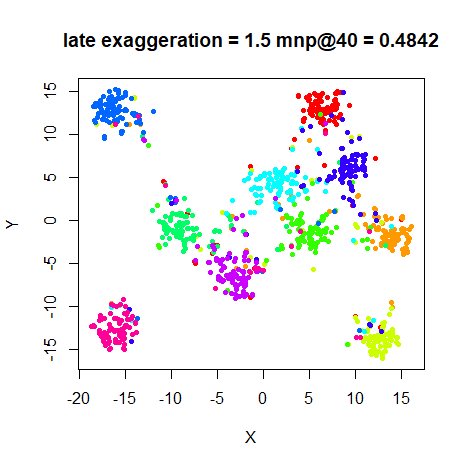

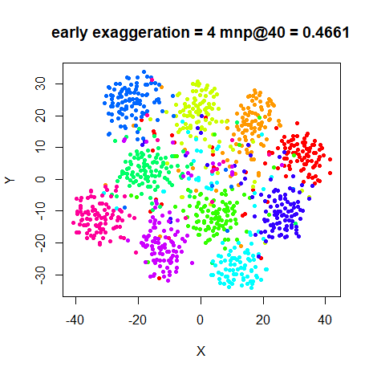

### oli

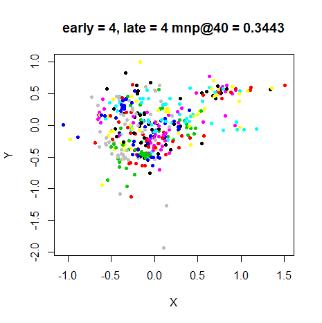

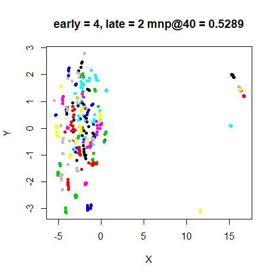

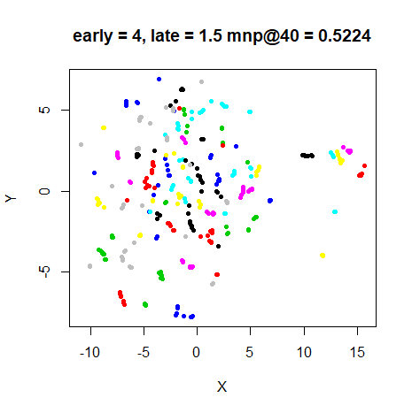

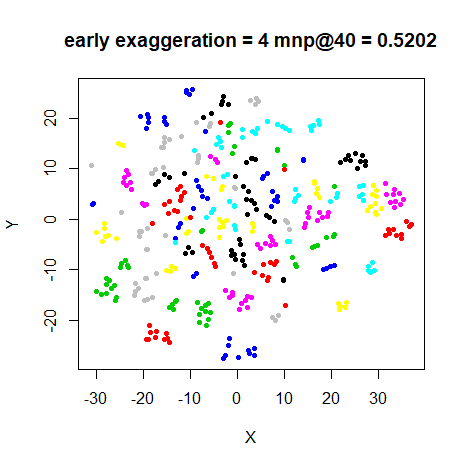

### frey

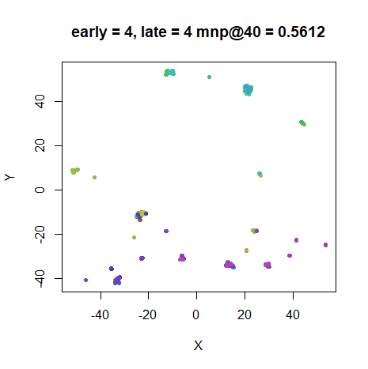

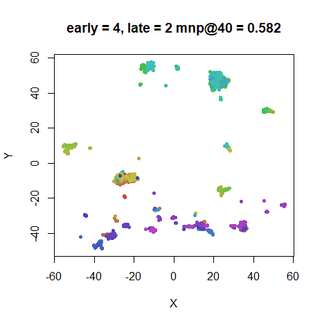

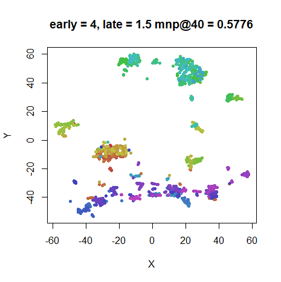

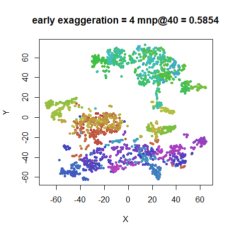

### coil20

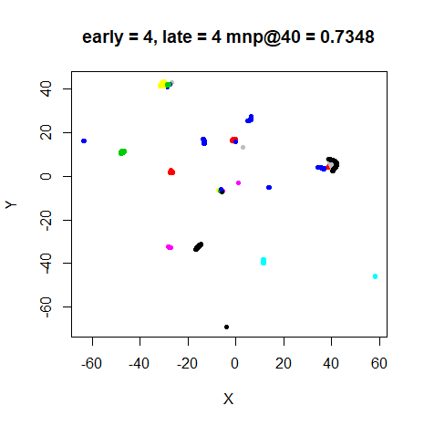

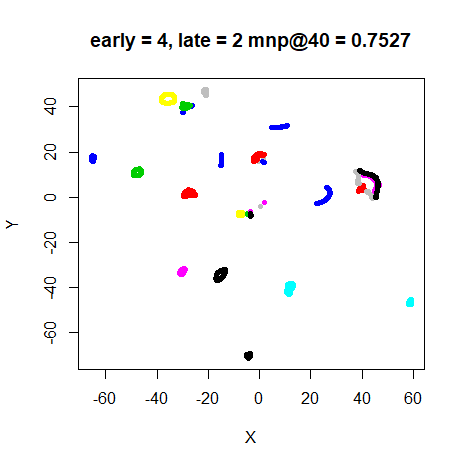

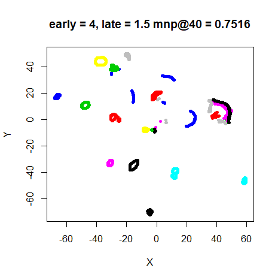

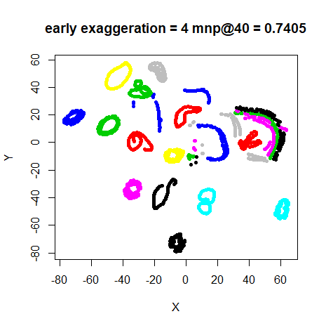

### mnist

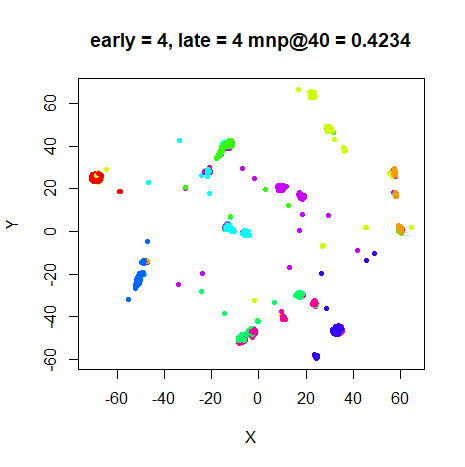

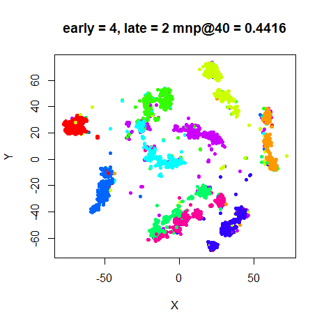

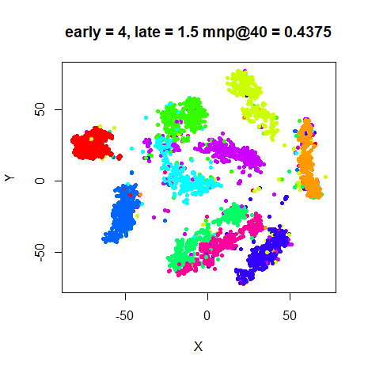

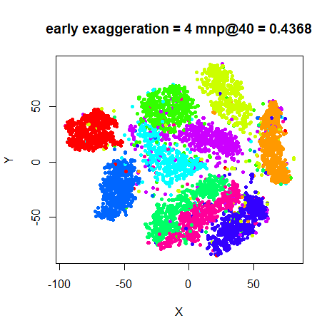

### fashion

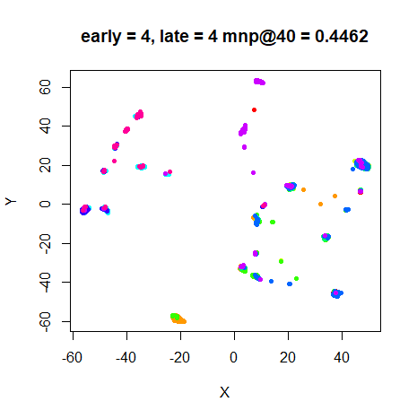

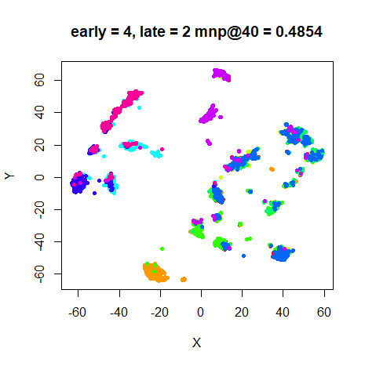

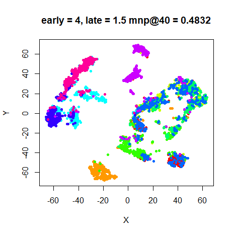

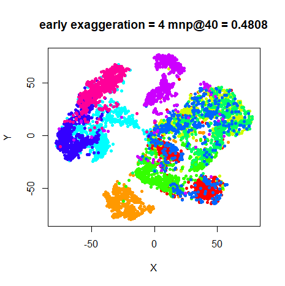